# Code Sample Long

2022-09-26

## load Packages

```r
library(data.table)
library(tidyverse)
library(lubridate)
library(rai)
library(caret)
```

# Import data

## Thoughts

Do we need a lag? Meaning: are google trends coming into account later (for sure, but whats the timespan)? Can we measure this? If so, how?

## Assignment

Number of nights spent at tourist accommodation establishments (Eurobase code: TOUR_OCC_NIM, UNIT:NR, NACE R2: I551-I553, INDIC TO: B006)

In case there is no available reference to INDIC TO: B006 in the data, use the following setting: TOUR_OCC_NIM, UNIT:NR, NACE R2:I1551-I1553, TOTAL.

The published figures are available here - and the task of each team is to nowcast the values of this monthly indicator for September 2022 until April 2023.

In this phase, each team submits nowcasts (according to the approaches that they have developed) for the number of tourism nights spent at tourist accommodation establishments (tourism) indicator. The team can make up to 5 different entries, using different approaches. For each entry, nowcasts (in the form of point estimates) must be submitted for *at least 5 countries* (chosen by the team) for a given month. (For example, if the current reference period is September 2022, the teams will have to provide the point estimates for 5 or more countries to have a valid entry for September 2022.) For an entry to be considered in the evaluation phase, there must be *at least 6 consecutive monthly submissions* for each of at least 5 countries. Each monthly submission of an entry needs to be accompanied by a brief description of the approach used.

## Indicators

```r
datapath = "../data/"
ind_path = paste0(datapath, "indicators/")
list.files(ind_path)
```

```
## [1] "tour_occ_nim_custom.csv"     "tour_occ_nim_linear_all.csv"
```

```r
ind_in = fread(paste0(ind_path,"tour_occ_nim_custom.csv"))

ind_t1 = ind_in[,-c(1:3)] %>%
  as_tibble() %>%
  mutate(month_end = as_date(paste0(TIME_PERIOD,"-01")),.before=1)

ind_t1 %>% select(nace_r2) %>% distinct()
```

```
## # A tibble: 2 × 1
##   nace_r2
##   <chr>
## 1 I551-I553
## 2 I552_I553
```

```r
## Scale
scale2 <- function(x, na.rm = FALSE) (x - mean(x, na.rm = na.rm)) / sd(x, na.rm)

ind_de= ind_t1 %>%
  filter(geo == "IT" & nace_r2 == "I551-I553" & unit=="NR" & c_resid=="TOTAL") %>%
  mutate(obs_value_std = scale2(OBS_VALUE),
         obs_value_norm = (OBS_VALUE-mean(OBS_VALUE))/max(abs(OBS_VALUE-mean(OBS_VALUE))),
         obs_value_max = OBS_VALUE/max(OBS_VALUE)
         )

ind_stats = ind_de %>%
  summarise(mean=mean(OBS_VALUE),
            sd=sd(OBS_VALUE),
            max=max(OBS_VALUE),
            norm=max(abs(OBS_VALUE-mean(OBS_VALUE)))
            )
```

Therefore, the stats are:

```r
ind_stats
```

```
## # A tibble: 1 × 4
##        mean        sd      max      norm
##       <dbl>     <dbl>    <int>     <dbl>
## 1 28094060. 20398888. 84573606 56479546.
```

## Google Trends Short Term

Idea: Use short term data as test and validation set, also to veryfy the concept.

```r
goo_path = paste0(datapath, "googleTrends/")
list.files(goo_path)
```

```
##  [1] "Belgium1.csv"                 "Bulgaria1.csv"
##  [3] "Czech1.csv"                   "Denmark1.csv"
##  [5] "europa_de_week.csv"           "europa_world_week.csv"
##  [7] "Germany_germany_weekly.csv"   "Germany_worldwide_weekly.csv"
##  [9] "Germany1.csv"                 "Germany1_full.csv"
## [11] "Germany1_full.csv.bak"        "Germany1_month.csv"
## [13] "Germany1_month.csv.bak"       "Germany1_weekly.csv"
## [15] "SearchGermany1.csv"
```

```r
series = c("Belgium1.csv", "Bulgaria1.csv", "Czech1.csv", "Denmark1.csv", "Germany1.csv")
input = paste0(goo_path, series)
in_list_week =input %>% map(~fread(., skip=2))
in_list_week = map(in_list_week, as_tibble)
#
# df_week = reduce(.x = in_list_week, .f = full_join)
# div_100 = function(x) (x/100)
# df_week = df_week %>% mutate(across(.cols = 2:6, scale2))
#
# df_week_cl = df_week %>%
#    rename(eur_world=`europa: (Weltweit)`,
#           eur_de=`europa: (Deutschland)`,
#           de_de=`deutschland: (Deutschland)`,
#           de_world=`deutschland: (Weltweit)`,
#           tourism_de=`tourism: (Deutschland)`
#           ) %>%
#   mutate(week_end = Woche + 7, .before=2) %>%
#   mutate(month_end = floor_date(week_end, unit="month"), .before=3)
#
# month_cnt = df_week_cl %>% select(month_end) %>% group_by(month_end) %>% summarise(n=n())
# ggplot(data=month_cnt, aes(x=month_end, y=n)) +
#   geom_col()
```

```r
# df_cl_month = df_week_cl %>%
#   select(!week_end) %>%
#   group_by(month_end) %>%
#   summarise(across(.cols = 2:6, mean))
#
# df_cl_month %>%
#   gather(key=series, value=value,-month_end) %>%
#   ggplot(aes(x=month_end, y=value, color=series)) +
#   geom_line()
```

## Google Trends Longterm

Two options: Use data starting in 2004 or 2011.

```r
series = "Germany1_full.csv"
input = paste0(goo_path, series)
# in_list =input %>% map(~fread(., skip=2))
# in_list = map(in_list, as_tibble)
# df = reduce(.x = in_list, .f = full_join)

df_mon = fread(input, skip = 2) %>% as_tibble()

div_100 = function(x) (x/100)
df_mon = df_mon %>% mutate(across(.cols = 2:6, scale2))

df_mon_cl = df_mon %>%
   rename(tour_de=`Tourismus: (Deutschland)`,
          nights_de=`Übernachtungen: (Deutschland)`,
          lastm_de=`last minute: (Deutschland)`,
          allincl_de=`All inclusive: (Deutschland)`,
          goofl_de=`Google Flüge: (Deutschland)`
          ) %>%
  mutate(month_end = as_date(paste0(Monat,"-01")),.before=1) %>%
  select(!Monat)
```

# Combine data

```r
df_de = ind_de[,-c(2:6,8)] %>%
  full_join(df_mon_cl, by="month_end") %>%
  filter(!is.na(tour_de))

theResponse=df_de %>%
  filter(!is.na(obs_value_std)) %>%
  .$obs_value_std

theData = df_de %>%
  filter(!is.na(obs_value_std)) %>%
  .[6:10]
```

# Test

## LM

```r
mod_lm =caret::train(x=theData, y=theResponse, method="lm")
summary(mod_lm)
```

```
##
## Call:
## lm(formula = .outcome ~ ., data = dat)
##
## Residuals:
##     Min      1Q  Median      3Q     Max
## -2.7709 -0.3879 -0.1146  0.2414  2.2407
##
## Coefficients:
##             Estimate Std. Error t value Pr(>|t|)
## (Intercept)  0.13786    0.04491   3.070  0.00242 **
## tour_de     -0.30937    0.06533  -4.735 3.95e-06 ***
## nights_de   -0.11870    0.06830  -1.738  0.08363 .
## lastm_de     0.98490    0.06970  14.130  < 2e-16 ***
## allincl_de   0.13041    0.07650   1.705  0.08970 .
## goofl_de    -0.27888    0.06782  -4.112 5.56e-05 ***
## ---
## Signif. codes:  0 '***' 0.001 '**' 0.01 '*' 0.05 '.' 0.1 ' ' 1
##
## Residual standard error: 0.6705 on 217 degrees of freedom
## Multiple R-squared:  0.6144, Adjusted R-squared:  0.6055
## F-statistic: 69.16 on 5 and 217 DF,  p-value: < 2.2e-16
```

We do need more data! Seems that google trends monthly data should be sufficient!

## RAI

```r
rai_out = rai(theData, theResponse)
summary(rai_out$model)
```

```
##
## Call:
## lm(formula = aucOut$formula, data = data.frame(y = theResponse,
##     aucOut$subData))
##
## Residuals:
##      Min       1Q   Median       3Q      Max
## -1.12526 -0.30923 -0.05708  0.20827  1.94376
##
## Coefficients:
##                                           Estimate Std. Error t value Pr(>|t|)
## (Intercept)                               0.552500   0.086638   6.377 1.10e-09
## I(lastm_de)                               1.401962   0.069072  20.297  < 2e-16
## I(lastm_de * lastm_de)                   -0.192771   0.028105  -6.859 7.40e-11
## I(tour_de)                               -0.163316   0.099533  -1.641 0.102310
## I(tour_de * tour_de)                     -0.581381   0.098368  -5.910 1.34e-08
## I(tour_de * tour_de * tour_de * tour_de)  0.041051   0.007782   5.275 3.25e-07
## I(goofl_de)                              -0.438626   0.130072  -3.372 0.000886
## I(goofl_de * goofl_de)                    0.089355   0.039682   2.252 0.025356
## I(lastm_de * tour_de)                     0.315440   0.094206   3.348 0.000961
## I(lastm_de * tour_de * tour_de)          -0.085015   0.034476  -2.466 0.014456
##
## (Intercept)                              ***
## I(lastm_de)                              ***
## I(lastm_de * lastm_de)                   ***
## I(tour_de)
## I(tour_de * tour_de)                     ***
## I(tour_de * tour_de * tour_de * tour_de) ***
## I(goofl_de)                              ***
## I(goofl_de * goofl_de)                   *
## I(lastm_de * tour_de)                    ***
## I(lastm_de * tour_de * tour_de)          *
## ---
## Signif. codes:  0 '***' 0.001 '**' 0.01 '*' 0.05 '.' 0.1 ' ' 1
##
## Residual standard error: 0.5376 on 213 degrees of freedom
## Multiple R-squared:  0.7567, Adjusted R-squared:  0.7464
## F-statistic: 73.62 on 9 and 213 DF,  p-value: < 2.2e-16
```

## Bayesian reg NN

```r
theData = as.data.frame(theData)
fitControl <- caret::trainControl(method = "repeatedcv",
                            number = 5, ## 5-fold CV...
                            repeats = 5)  ## repeated 5 times
mod_brnn =caret::train(x=theData, y=theResponse, method="brnn", trControl = fitControl, verbose=F)
```

[output not shown]

[output cut: 249 more lines]

[output not shown]

```r
mod_brnn
```

```
## Bayesian Regularized Neural Networks
##
## 223 samples
##   5 predictor
##
## No pre-processing
## Resampling: Cross-Validated (5 fold, repeated 5 times)
## Summary of sample sizes: 179, 178, 179, 179, 177, 179, ...
## Resampling results across tuning parameters:
##
##   neurons  RMSE       Rsquared   MAE
##   1        0.6281491  0.6602835  0.4388033
##   2        0.5872302  0.7126118  0.4305305
##   3        0.5638979  0.7349352  0.4009091
##
## RMSE was used to select the optimal model using the smallest value.
## The final value used for the model was neurons = 3.
```

```r
#predict(mod_brnn, df_de[c(59:60),6:9])
```

## Deep Autoencoder (not working)

Something is wrong; all the RMSE metric values are missing:

```r
fitControl <- caret::trainControl(method = "repeatedcv",
                            number = 5, ## 5-fold CV...
                            repeats = 5)  ## repeated 5 times
mod_nn =caret::train(x=theData, y=theResponse, method="dnn", trControl = fitControl, verbose=F)
```

```r
mod_nn
predict(mod_nn, df_de[c(59:60),6:9])
```

[output not shown]

## GBM

```r
gbmGrid <-  expand.grid(interaction.depth = c(1:4),
                        n.trees = (1:50),
                        shrinkage = 0.1,
                        n.minobsinnode = 5)

fitControl <- caret::trainControl(method = "repeatedcv",
                            number = 5, ## 5-fold CV...
                            repeats = 10)  ## repeated 5 times
mod_gbm =caret::train(x=theData, y=theResponse, method="gbm", trControl = fitControl, tuneGrid=gbmGrid, verbose=F)
```

```r
#mod_gbm
mod_gbm$bestTune
```

```
##     n.trees interaction.depth shrinkage n.minobsinnode
## 200      50                 4       0.1              5
```

```r
mod_gbm$results %>% filter(n.trees==33 & interaction.depth==1 & shrinkage == 0.1 & n.minobsinnode==5)
```

```
##   shrinkage interaction.depth n.minobsinnode n.trees      RMSE  Rsquared
## 1       0.1                 1              5      33 0.6616632 0.6360982
##         MAE     RMSESD RsquaredSD      MAESD
## 1 0.4987809 0.07112742 0.08910543 0.04890352
```

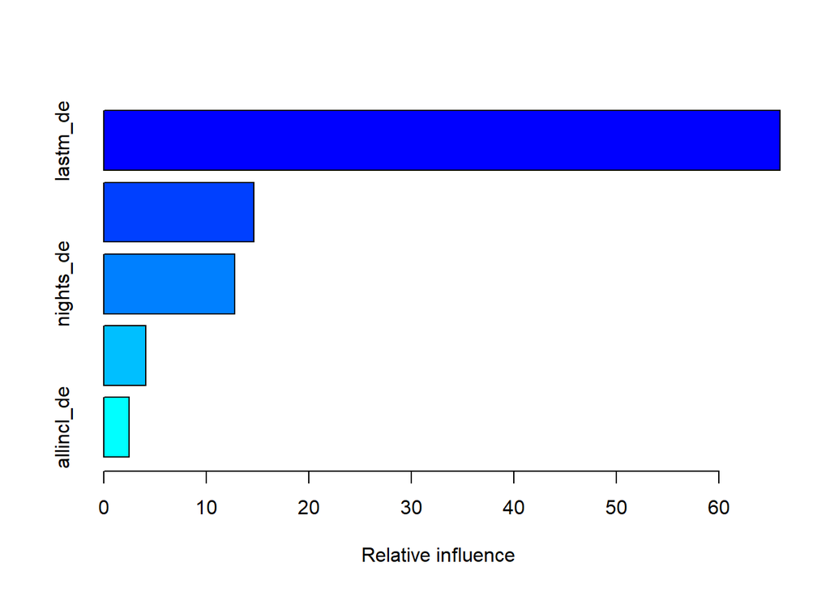

```
##                   var   rel.inf
## lastm_de     lastm_de 65.975187
## tour_de       tour_de 14.665700
## nights_de   nights_de 12.781387
## goofl_de     goofl_de  4.130448
## allincl_de allincl_de  2.447278
```

```r
summary(mod_gbm)
```

```r
# predict(mod_gbm, df_de[c(59:60),6:9])
```

## SVN

http://topepo.github.io/caret/train-models-by-tag.html#support-vector-machines

Die sehen sehr vielversprechend aus! Das sollte man weiter verfolgen.

```r
fitControl <- caret::trainControl(method = "repeatedcv",
                            number = 5, ## 5-fold CV...
                            repeats = 5)  ## repeated 5 times
mod_svn =caret::train(x=theData, y=theResponse, method="svmRadialSigma", trControl = fitControl, verbose=F)
```

```r
mod_svn
```

```
## Support Vector Machines with Radial Basis Function Kernel
##
## 223 samples
##   5 predictor
##
## No pre-processing
## Resampling: Cross-Validated (5 fold, repeated 5 times)
## Summary of sample sizes: 179, 178, 178, 178, 179, 179, ...
## Resampling results across tuning parameters:
##
##   sigma       C     RMSE       Rsquared   MAE
##   0.04820961  0.25  0.7083921  0.6842594  0.4763113
##   0.04820961  0.50  0.6284615  0.7207094  0.4118346
##   0.04820961  1.00  0.5900164  0.7401861  0.3815670
##   0.57740327  0.25  0.6528627  0.7322121  0.4231748
##   0.57740327  0.50  0.5700552  0.7697718  0.3699987
##   0.57740327  1.00  0.5290356  0.7847316  0.3454030
##   1.10659692  0.25  0.7372499  0.6692265  0.4693461
##   1.10659692  0.50  0.6425847  0.7102049  0.4116531
##   1.10659692  1.00  0.6044415  0.7166454  0.3917508
##
## RMSE was used to select the optimal model using the smallest value.
## The final values used for the model were sigma = 0.5774033 and C = 1.
```

```r
summary(mod_svn)
```

```
## Length  Class   Mode
##      1   ksvm     S4
```

```r
# predict(mod_svn, df_de[c(59:60),6:9])
```

# Compare results:

```r
# res_tab = tibble(
#   lm = predict(mod_lm,df_de[c(59:60),6:9]),
#   brnn = predict(mod_brnn, df_de[c(59:60),6:9]),
#   gbm = predict(mod_gbm, df_de[c(59:60),6:9]),
#   svn = predict(mod_svn, df_de[c(59:60),6:9])
# )

res_stats = as_tibble(getTrainPerf(mod_lm)) %>%
  add_row(getTrainPerf(mod_brnn)) %>%
  add_row(getTrainPerf(mod_gbm)) %>%
  add_row(getTrainPerf(mod_svn))

# res_tab
res_stats
```

```
## # A tibble: 4 × 4
##   TrainRMSE TrainRsquared TrainMAE method
##       <dbl>         <dbl>    <dbl> <chr>
## 1     0.718         0.593    0.494 lm
## 2     0.564         0.735    0.401 brnn
## 3     0.474         0.807    0.332 gbm
## 4     0.529         0.785    0.345 svmRadialSigma
```

```r
summary(rai_out$model)
```

```
##
## Call:
## lm(formula = aucOut$formula, data = data.frame(y = theResponse,
##     aucOut$subData))
##
## Residuals:
##      Min       1Q   Median       3Q      Max
## -1.12526 -0.30923 -0.05708  0.20827  1.94376
##
## Coefficients:
##                                           Estimate Std. Error t value Pr(>|t|)
## (Intercept)                               0.552500   0.086638   6.377 1.10e-09
## I(lastm_de)                               1.401962   0.069072  20.297  < 2e-16
## I(lastm_de * lastm_de)                   -0.192771   0.028105  -6.859 7.40e-11
## I(tour_de)                               -0.163316   0.099533  -1.641 0.102310
## I(tour_de * tour_de)                     -0.581381   0.098368  -5.910 1.34e-08
## I(tour_de * tour_de * tour_de * tour_de)  0.041051   0.007782   5.275 3.25e-07
## I(goofl_de)                              -0.438626   0.130072  -3.372 0.000886
## I(goofl_de * goofl_de)                    0.089355   0.039682   2.252 0.025356
## I(lastm_de * tour_de)                     0.315440   0.094206   3.348 0.000961
## I(lastm_de * tour_de * tour_de)          -0.085015   0.034476  -2.466 0.014456
##
## (Intercept)                              ***
## I(lastm_de)                              ***
## I(lastm_de * lastm_de)                   ***
## I(tour_de)
## I(tour_de * tour_de)                     ***
## I(tour_de * tour_de * tour_de * tour_de) ***
## I(goofl_de)                              ***
## I(goofl_de * goofl_de)                   *
## I(lastm_de * tour_de)                    ***
## I(lastm_de * tour_de * tour_de)          *
## ---
## Signif. codes:  0 '***' 0.001 '**' 0.01 '*' 0.05 '.' 0.1 ' ' 1
##
## Residual standard error: 0.5376 on 213 degrees of freedom
## Multiple R-squared:  0.7567, Adjusted R-squared:  0.7464
## F-statistic: 73.62 on 9 and 213 DF,  p-value: < 2.2e-16
```

Last but not least: Variable importance:

```r
varImp(mod_svn)
```

```
## loess r-squared variable importance
##
##            Overall
## lastm_de    100.00
## tour_de      31.66
## allincl_de   24.36
## nights_de    15.63
## goofl_de      0.00
```